# ISYE 6420: Homework 1

aelhabr3

# 1. Circuit

## Instructions

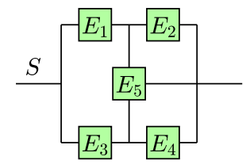

Figure 1: Components $E_1,\dots E_4$ at operational at time $t$ with probabilities $e^{−t}, e^{−2t}, e^{−t/2}, e^{−t/3}$ and $e^{−t}$, respectively.  
The system $S$ consists of five independent elements $E_i$, $i = 1, \dots , E_5$, connected as in Figure 1. Probability that the element $E_i$ is operational at the end of time interval $[0,t]$ is given as

$$\begin{array}{cc}
p_i(t) = e^{-\lambda_i t}, & t \geq 0,
\end{array}$$

for $\lambda_1 = 1, \lambda_2 = 2, \lambda_3 = 1/2, \lambda_4 = 1/3, \lambda_5 = 1$.  
(a) Find the probability that the system $S$ will be operational at time $t$. Plot this probability as a function of time $t$. What is this probability for $t = 1/2$?  
(b) Find the probability that component $E_5$ was operational at time $t = 1/2$, if the system was operational at that time.  
Hint: If you consider (b), it is conditional probability, more precisely, a posterior probability of the hypothesis $H_1: E_5$ operational at time $t$, given that system S is operational at t. Thus, solve part (a) as a total probability with $H1$ and $H_2 = H_1^C$ as hypotheses. Under the two hypotheses the system simplifies as in Figure 2 and it is easy to find $P(S|H_1)$ and $P(S|H_2)$. Then (b) is just a Bayes formula. The results for arbitrary t will be messy - do not simplify. For plotting in part (a) take some reasonable interval for time $t$, say $[0, 4]$.

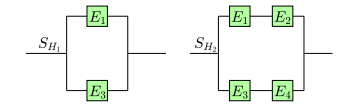

Figure 2: Left: System under hypothesis $H_1 : E_5$ operational; Right: System under hypothesis $H_2 : E_5$ not operational.

## Response

Reference(s): + Exercises35: Cross-linked System + 2018f-hw01-q1 + 2019s-hw01-q1

### (a)

Reference(s): + 2018f-hw01-q1: Circuit + 2019s-hw01-q1-a: Circuit

We first formulate $P(S|H_1)$ (using the notation of the hint) as follows.

$$\begin{array}{lcl}
P(S|H_1) & = & 1 - P((E_1 \cup E_3)') \\
& = & 1 - P(E_1' \cap E_3') \\
& = & 1 - (1 - P(E_1)) (1 - P(E_3)) \\
& = & 1 - (1 - e^{-t}) (1 - e^{-t/2}) \\
& = & 1 - (1 - e^{-t} - e^{-t/2} + e^{t^2/2}) \\
& = & e^{-t} + e^{-t/2} - e^{-3t/2}.
\end{array}$$

Note that $P((E_1 \cup E_3)'$ represents the probability that neither $E_1$ nor $E_3$ works, which can also be expressed as $P(E_1' \cap E_3')$, which, in words, represents the probability that both $E_1$ and $E_3$ fail. (This is just a consequence of [De Morgan’s laws](https://en.wikipedia.org/wiki/De_Morgan%27s_laws).)

Also, note that we achieved the same result more directly using the [addition law of probability](https://en.wikipedia.org/wiki/Probability_axioms#Further_consequences), which corresponds to the expression $P(S|H_1) = P(E_1) + P(E_3) - P(E_1 \cap E_3)$ here.

Similarly, we can find $P(S|H_2)$ as follows.

$$\begin{array}{lcl}
P(S|H_2) & = & 1 - P((E_1 \cap E_2 ) \cup (E_3 \cap E_4)) \\
& = & 1 - (1 - P(E_1) P(E_2)) (1 - P(E_3) P(E_4)) \\
& = & 1 - (1 - e^{-t} e^{-2t}) (1 - e^{-t/2} e^{-t/3}) \\
& = & 1 - (1 - e^{-3t}) (1 - e^{-5t/6}) \\
& = & e^{-3t} + e^{-5t/6} - e^{-23t/6}.
\end{array}$$

Then, by [the law of total probability](https://en.wikipedia.org/wiki/Law_of_total_probability), it follows that

$$\begin{array}{lcl}
P(S) & = & P(S|H_1) P(H_1) + P(S|H_2) P(H_2) P(H_2) \\
& = & P(S|H_1) P(H_1) + P(S|H_2) P(H_2) (1 - P(H_1)) \\
& = & (e^{-t} + e^{-t/2} - e^{-3t/2}) (e^{-t}) + (e^{-3t} + e^{-5t/6} - e^{-23t/6}) (1 - e^{-t}).
\end{array}$$

We can write functions in `R` to codify these formulations.

```r
f_sh1 <- function(t) {
  exp(-t) + exp(-t / 2) - exp(-3 * t / 2)
  # Or
  # 1 - (1 - exp(-t)) * (1 - exp(-t / 2))
}
f_sh2 <-  function(t) {
  exp(-3 * t) + exp(-5 * t / 6) - exp(-23 * t / 6)
  # Or
  # 1 - (1 - exp(-t) * exp(-2 * t)) * (1 - exp(-t / 2) * exp(-t / 3))
}
f_h1 <- function(t) {
  exp(-t)
}
f_h2 <- function(t) {
  1 - f_h1(t)
}
f_s <- function(t) {
  f_sh1(t) * f_h1(t) + f_sh2(t) * f_h2(t)
}
```

And, finally, we can use these functions (namely, the last one defined above) to calculate the probability that the system $S$ will be operational at time $t = 0.5$.

```r
t_x <- 0.5
p_s_x <- f_s(t_x)
p_s_x
```

```
## [1] 0.8430491
```

We find that $P(S) = 0.843$ at $t = 0.5$.

Below is a plot of this probability as a function of time $t$ for $0 \leq t \leq 4$.

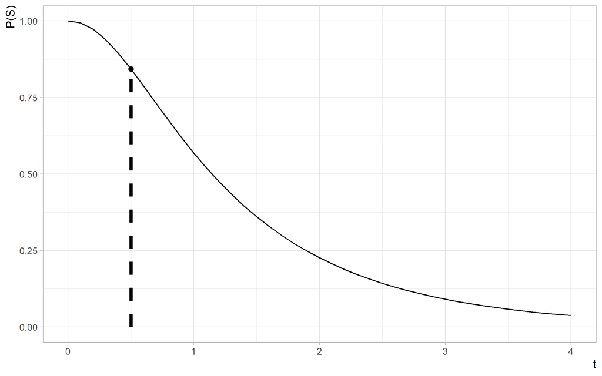

### (b)

Reference(s): + 2019s-hw01-q1-b: Circuit

See the formulation for $P(H_1|S)$ below.

$$\begin{array}{lcl}
P(H_1|S) & = & \frac{P(S|H_1) P(H_1)}{P(S)} \\
& = & \frac{(e^{-t} + e^{-t/2} - e^{-3t/2}) (e^{-t})}{(e^{-t} + e^{-t/2} - e^{-3t/2}) (e^{-t}) + (e^{-3t} + e^{-5t/6} - e^{-23t/6}) (1 - e^{-t})}.
\end{array}$$

We can implement this in `R` as follows.

```r
f_h1s <- function(t) {
  f_sh1(t) * f_h1(t) / f_s(t)
}
p_h1s_x <- f_h1s(t_x)
p_h1s_x
```

```
## [1] 0.6568315
```

We find that $P(H_1|S) = 0.657$ at at $t = 0.5$.

# 2. Two Batches

## Instructions

There are two batches of the same product. In one batch all products are conforming. The other batch contains 20% non-conforming products. A batch is selected at random and one randomly selected product from that batch is inspected. The inspected product was found conforming and was returned back to its batch. What is the probability that the second product, randomly selected from the same batch, is found non-conforming?  
Hint: This problem uses both Bayes’ rule and Total Probability. The two hypotheses concern the type of batch. For the first draw the hypotheses are equally likely (the batch is selected at random), but for the second draw, the probabilities of hypotheses are updated by the information on the result of the first draw via Bayes rule. Updated probabilities of hypotheses are then used in the Total Probability Formula for the second draw.

## Response

Let $B_1$ and $B_2$ represent the batch with all conforming products and the batch with 20% non-conforming products respectively. Also, let $C=1$ and $C=0$ denote conforming and non-conforming samples respectively. The problem description indicates that $P(B_1) = P(B_2) = 0.5, P(C=1|B_1)=1, P(C=1|B_2)=0.8$, where the $P(B_1), P(B_2)$ terms represent prior probabilities.

The prior probability $P(C=1)$ is as follows.

$$\begin{array}{lcl}
P(C=1) & = & P(C=1|B_1) P(B_1) + P(C=1|B_2) P(B_2) \\
& = & (1) (\frac{1}{2}) + (0.8) (\frac{1}{2}) \\
& = & 0.5 + 0.4 \\
& = & 0.9.
\end{array}$$

After we see that $C=1$ for the first selection, we formulate the posterior probability $P(B_1|C=1)$ as follows.

$$\begin{array}{lcl}
P(B_1|C=1) & = & \frac{P(C=1|B_1) P(B_1)}{P(C=1|B_1) P(B_1) + P(C=1|B_2) P(B_2)} \\
& = & \frac{(1)(0.5)}{(1)(0.5)+(0.8)(0.5)} \\
& = & \frac{0.5}{0.5+0.4} = \frac{5}{9} \approx 0.555.
\end{array}$$

$$\begin{array}{lcl}
P(B_1|C=1) & = & \frac{P(C=1|B_1) P(B_1)}{P(C=1)} \\
& = & \frac{(1)(0.5)}{0.9} \\
& \approx & 0.555.
\end{array}$$

Then we can update $P(C=1)$ as follows.

$$\begin{array}{lcl}
P(C=1) & = & P(C=1|B_1) P(B_1) + P(C=1|B_2) P(B_2) \\
& = & P(C=1|B_1) P(B_1) + P(C=1|B_2) (1 - P(B_1)) \\
& = & (1) (\frac{5}{9}) + (0.8) (1 - (\frac{5}{9})) \\
& = & \frac{41}{45} \approx 0.911.
\end{array}$$

Finally, we find that $P(C=0) = 1 - P_1(C=1) = \frac{4}{45} \approx 0.089$. This the updated probability that a product is found non-conforming (i.e. the probability that the second product is found non-conforming given that the first product is found conforming).

# 3. Classifier

## Instructions

In a machine learning classification procedure the items are classified as 1 or 0. Based on a training sample of size 120 in which there are 65 1’s and 55 0’s, the classifier predicts 70 1’s and 50 0’s. Out of 70 items predicted by the classifier as 1, 52 are correctly classified.  
From the population of items where the proportion of 0-labels is 99% (and 1-labels 1%), an item is selected at random. What is the probability that the item is of label 1, if the classifier says it was.  
Hint: Think about the following interpretation. If **$1$** is a specific disease present, **$0$** no disease present, and the classifier is a medical test for the disease, then you are asked to find a positive predictive value of a test for a subject coming from population where the prevalence of the disease is 1%.

## Response

Reference(s): + Exercises35: Alzheimer’s

First, let $X$ represent the actual value and $Y$ represent the predicted value. Next, let’s consider a general two-by-two [“confusion matrix”](https://en.wikipedia.org/wiki/Confusion_matrix) and it’s relationship to counts of true positives (TP), true negatives (TN), false positives (FP), and false negatives (FN).

$$\begin{array}{cc|cc}
& & \text{Predicted} & \\
& & Y=0 & Y=1 \\ \hline
\text{Actual} & X=0 & TN & FP \\
& X=1 & FN & TP \\
\end{array}$$

Sensitivity = True Positive Rate (TPR) = TP / (TP + FN) Specificity = True Negative rate (TNR) = TN / (FP + TN) Positive predictive value (PPV) = TP / (TP + FP) Negative predictive value (PPV) = TN / (TN + FN)

Given the problem setup, the cells of the table are as follows. (The instruction-provided numbers are emphasized. The other values represent numbers derived from the instruction-provided values.)

$$\begin{array}{cc|cc|c}
& & \text{Predicted} & & \\
& & Y=0 & Y=1 & Y_{total} \\ \hline
\text{Actual} & X=0 & 37 & 18 & \textbf{55} \\
& X=1 & 13 & \textbf{52} & \textbf{65} \\
\hline
& X_{total} & \textbf{50} & \textbf{70} & \textbf{120}
\end{array}$$

The problem description indicates

$$\begin{array}{l}
P_{new}(X=0)=0.99, \\
P_{new}(X=1)=0.01.
\end{array}$$

We use the $_{new}$ subscript to indicate that the sample is the one where the prevalence of the disease is 1% (and don’t use a subscript for the “original” population).

Note that we would define

$$\begin{array}{l}
P(X=0)=\frac{55}{120}=\frac{11}{24}, \\
P(X=1)=\frac{65}{120}=\frac{13}{24}
\end{array}$$

if we were to use the original population.

Additionally, we identify the following from the original population

$$\begin{array}{l}
P(Y=1|X=1) = \frac{52}{65} = \frac{4}{5}, \\
P(Y=1|X=0)=\frac{18}{55}.
\end{array}$$

Next, let’s create “placeholder” expressions $A, B$ (to simplify notation) as follows.

$$A_{new} = P(Y=1|X=1) P_{new}(X=1) = (\frac{4}{5}) (0.01) = 0.008.$$

and

$$B_{new} = P(Y=1|X=0) P_{new}(X=0) = (\frac{18}{55}) (0.99) = 0.324.$$

Then, using Bayes’ formula, we have the following.

$$\begin{array}{lcl}
P_{new}(X=1|Y=1) & = & \frac{P(Y=1|X=1) P_{new}(X=1)}{P(Y=1|X=1) P_{new}(X=1) + P(Y=1|X=0) P_{new}(X=0))} \\
& = & \frac{A_{new}}{A_{new}+B_{new}} \\
& = & \frac{(0.008)}{(0.008)+(0.324)} \\
& \approx & 0.02410.
\end{array}$$

Thus, we have found that the probability that the item is of label 1 if the classifier indicates that it is 1 is 0.02410.

Note that if we had used the original sample, we would have found a very different answer.

$$A = P(Y=1|X=1) P(X=1) = (\frac{4}{5}) (\frac{13}{24}) = \frac{13}{30}.$$

$$B = P(Y=1|X=0) P(X=0) = (\frac{18}{55}) (\frac{11}{24}) = \frac{3}{20}.$$

$$\begin{array}{lcl}
P(X=1|Y=1) & = & \frac{A}{A+B} \\
& \approx & 0.7429.
\end{array}$$

This is equivalent to the positive predictive value (PPV), which can be calculated directly from the original table.

$$PPV = TP / (TP + FP) = (52) / ((52 + 18)) = 52 / 70 \approx 0.7429.$$